# R 중급 통계분석 3일차 (2)

```r
ggplot(iris, aes(x=Petal.Length, y=Petal.Width)) + geom_point()
```

geom_point()의 도움말을 보면 다음과 같이 data, mapping, stat 등의 파라메터들이 있습니다. 이는 ggplot함수에서 설정한 data나 mapping 정보를 geom_point에서 설정 하거나 완전히 다른 데이터를 x축과 y축에 그릴 수 있다는 뜻 이기도 합니다.

```r
ggplot() +
  geom_point(data=iris, mapping=aes(x=Petal.Length, y=Petal.Width))
```

그런데 위 꽃잎의 길이와 넓이는 세 가지 다른 종류의 붓꽃에 대한 정보입니다. 따라서 각 종에 따라 다른 색이나 기호를 할당하는 것도 mapping에서 설정할 수 있습니다.

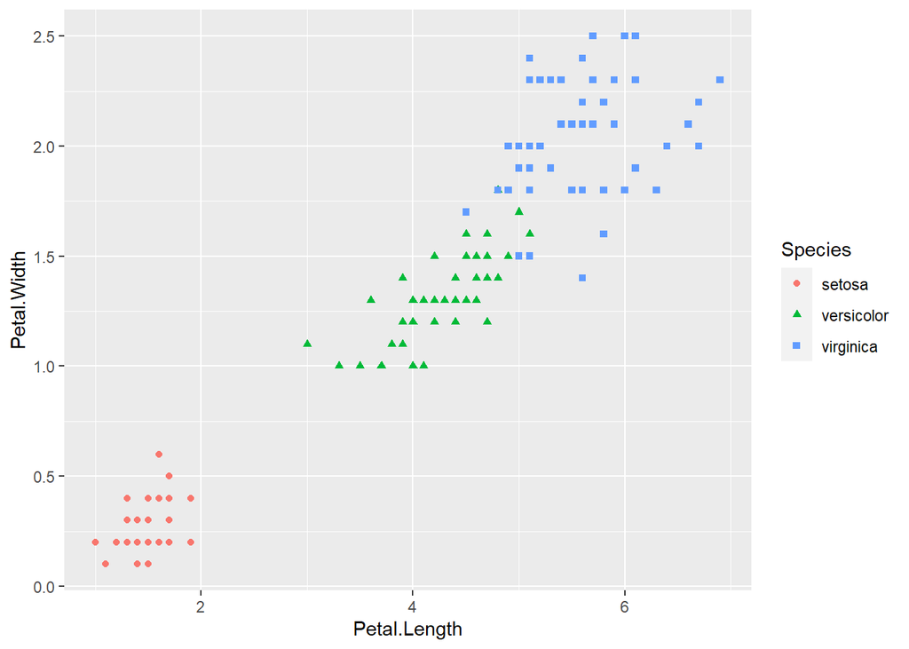

```r
ggplot(iris, aes(x=Petal.Length,
                 y=Petal.Width,
                 color=Species,
                 shape=Species)) +
  geom_point()
```

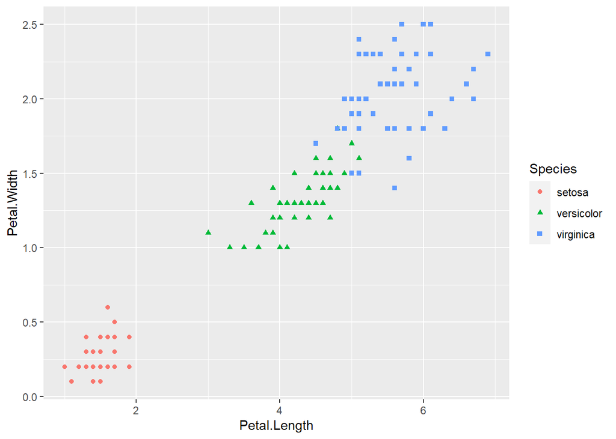

```r
ggplot(iris, aes(x=Petal.Length, y=Petal.Width)) +
  geom_point(aes(color=Species, shape=Species))
```

위 산점도들의 stat은 identity 입니다. 즉, 따로 통계량을 계산할 필요 없이 값 그 자체를 사용하겠다는 것 입니다. 히스토그램의 경우 geom_bar() 함수로 막대그래프를 그릴 수 있습니다. geom_bar의 help페이지를 보면 stat=“count”로 설정되어 있는 것을 알 수 있습니다. 꽃잎의 넓이에 대한 분포를 예로 구해봅니다. 히스토그램을 그릴경우 변수 한 개의 데이터만 필요하고 y축에는 자동으로 빈도수가 들어가게 되므로 aes에서 x만 mapping 해 주면 됩니다.

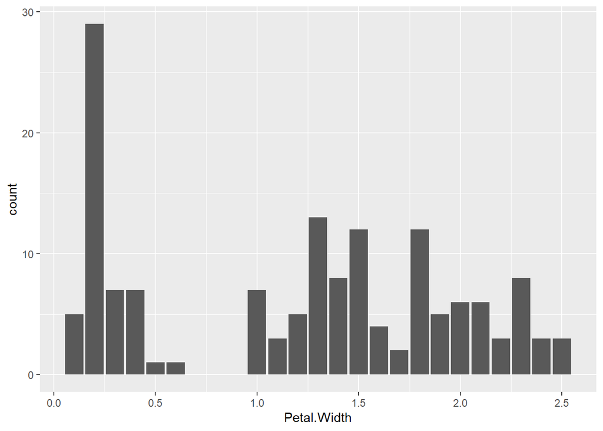

```r
ggplot(iris, aes(x=Petal.Width)) +
  geom_bar()
```

## 2. bar graph

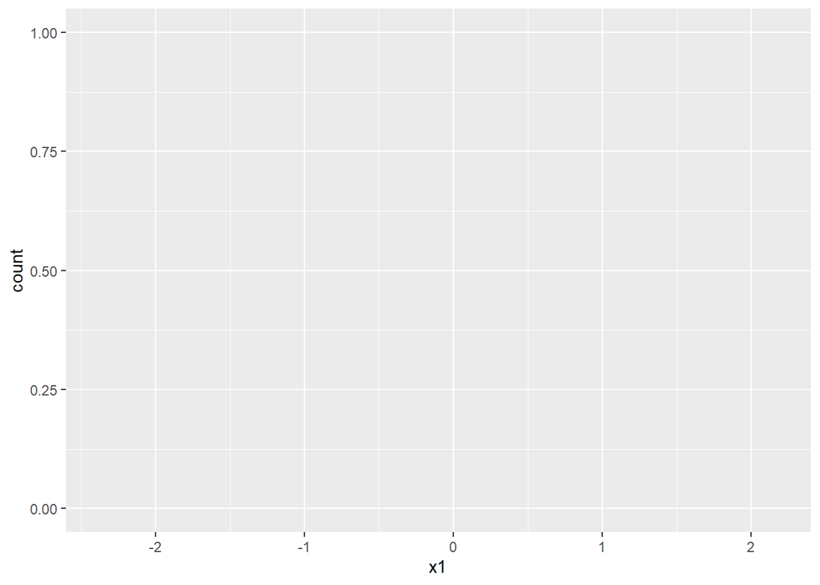

```r
set.seed(12314)
dat <- data.frame(x1=rnorm(100))
ggplot(dat, aes(x=x1)) +
  geom_bar()
```

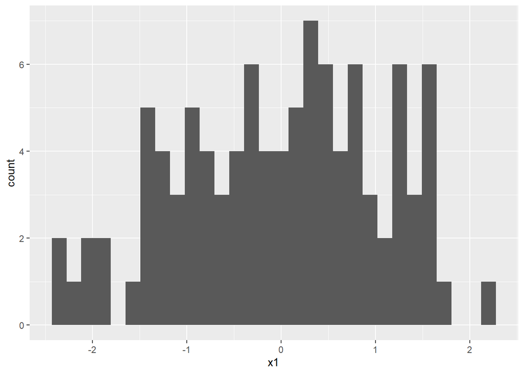

```r
ggplot(dat, aes(x=x1)) +
  geom_bar(stat="bin", bins=30)
```

x가 이산형인 경우는 stat을 디폴트 값인 count로 설정하여 해당 값들의 빈도수를 그려줄 수 있습니다. 이는 앞서 iris에서 배운 예제와 같습니다.

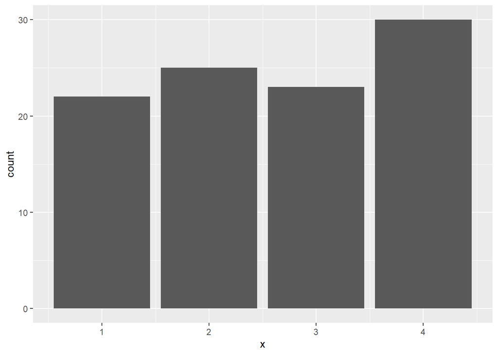

```r
x1 <- sample(1:4, 100, replace = T)
dat <- data.frame(x=x1)
ggplot(dat, aes(x=x)) +
  geom_bar(stat="count")
```

이제 두 개의 변수가 있는 경우를 생각해 봅니다.